# Sampling Distributions

## Sampling Distribution

When evaluating and interpreting a regression mode, it is necessary to understand that the slope and intercepts are estimates of an average. Given that there is some uncertainty in the accuracy of the estimate, We will often calculate what’s known as a Sampling Distribution. A sampling distribution is the distribution of estimated slopes or intercepts that could occur given the estimate is the law. Refer to the graphic below.

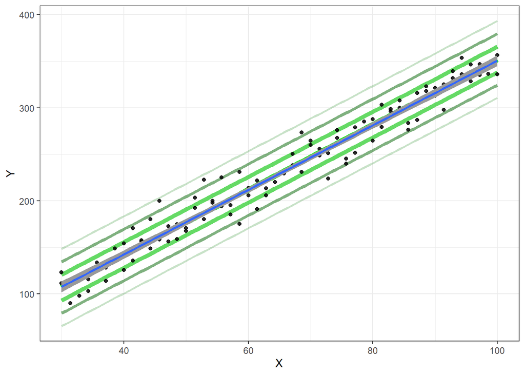

```r
#graph for intercept deviation
ggplot(data,aes(x=X,y=Y))+
  stat_function(fun=function(x) beta_0+beta_1*x, size = 2.5, color="green")+
  stat_function(fun=function(x) beta_0+sigma+beta_1*x, size = 2, color="limegreen", alpha = .75)+
  stat_function(fun=function(x) beta_0+sigma*2+beta_1*x, size = 1.5, color="darkgreen", alpha = .5)+
  stat_function(fun=function(x) beta_0+sigma*3+beta_1*x, size = 1, color="forestgreen", alpha = .25)+
  #for - std error
  stat_function(fun=function(x) beta_0-sigma+beta_1*x, size = 2, color="limegreen", alpha = .75)+
  stat_function(fun=function(x) beta_0-sigma*2+beta_1*x, size = 1.5, color="darkgreen", alpha = .5)+
  stat_function(fun=function(x) beta_0-sigma*3+beta_1*x, size = 1, color="forestgreen", alpha = .25)+
  # plot the points
  geom_point(color = "black", alpha = .85)+
  theme_bw()+
  geom_smooth(method='lm', alpha=1.0)
```

## P values and Confidence Intervals

The p-value for the slope and the intercept are calculated in much the same way a any p-value for another distribution. It is calculated by taking the difference between the estimate and the null hypothesis in the number of standard errors.

$$t = \frac{b_1 - \overbrace{0}^\text{Null Hypothesis}}{s_{b_1}}$$

The p-value in this case is the odds of achieving a given slope or intercept assuming the null hypothesis is true. If we use a 95% confidence interval, we expect 95% of all tested slopes or intercepts to fall within 2 standard errors of the null hypothesis. If the calculated slope and hypothesis falls outside of this 95% range, we would reject the null hypothesis and use the calculated slope and intercept as the null hypothesis.